# Lego Project

Andrés De Freitas Carmona

2024-11-09

# Lego Sets: An Analysis Project

The following project is a descriptive analysis on multiple Lego sets between 2018 and 2020. The goal of the project is to extract meaningful data and represent it in a comprehensible graphical format that could serve to improve decision making relative to the Lego market.

#### Libraries

```r
library (tidyverse)
library (ggplot2)
library (dplyr)
library (gridExtra)
```

#### Data loading

```r
setwd("C:/Users/andre/OneDrive/Escritorio/Lego Project")
lego_data <- read.csv("lego_population_cof.csv")
```

# 1. Data overview

The dataset offers plenty of variables to work with.

```r
str(lego_data)
```

```
## 'data.frame':    2307 obs. of  16 variables:
##  $ X            : int  1 2 3 4 5 6 7 8 9 10 ...
##  $ Item_Number  : chr  "-" "-" "-" "-" ...
##  $ Set_Name     : chr  NA NA NA NA ...
##  $ Amazon_Price : chr  "" "" "-" "-" ...
##  $ Year         : int  NA NA NA NA NA NA NA NA NA NA ...
##  $ Pages        : logi  NA NA NA NA NA NA ...
##  $ unique_pieces: int  NA NA NA NA NA NA NA NA NA NA ...
##  $ Theme        : chr  NA NA NA NA ...
##  $ Pieces       : int  NA NA NA NA NA NA NA NA NA NA ...
##  $ Price        : logi  NA NA NA NA NA NA ...
##  $ Ages         : chr  "Ages_NA" "Ages_NA" "Ages_NA" "Ages_NA" ...
##  $ Minifigures  : int  NA NA NA NA NA NA NA NA NA NA ...
##  $ Packaging    : chr  NA NA NA NA ...
##  $ Weight       : chr  NA NA NA NA ...
##  $ Availability : chr  NA NA NA NA ...
##  $ Size         : chr  NA NA NA NA ...
```

```r
lego_data %>% summarise_all(~ list(unique(.))) %>% pivot_longer(everything(), names_to = "Variable", values_to = "Unique_Values")
```

```
## # A tibble: 16 × 2
##    Variable      Unique_Values
##    <chr>         <list>
##  1 X             <int [2,307]>
##  2 Item_Number   <chr [1,922]>
##  3 Set_Name      <chr [1,298]>
##  4 Amazon_Price  <chr [373]>
##  5 Year          <int [4]>
##  6 Pages         <lgl [1]>
##  7 unique_pieces <int [346]>
##  8 Theme         <chr [48]>
##  9 Pieces        <int [637]>
## 10 Price         <lgl [1]>
## 11 Ages          <chr [35]>
## 12 Minifigures   <int [20]>
## 13 Packaging     <chr [13]>
## 14 Weight        <chr [247]>
## 15 Availability  <chr [8]>
## 16 Size          <chr [3]>
```

However, upon closer inspection, we can see some of those variables contain meaningless values, and even some variables themselves serve no purpose to our analysis. Data must be cleaned to proceed into the analysis.

# 2. Data cleaning

In this section, various changes into the data will take place, such as removing unnecessary columns, NA values, changing values to a more useful format and creating new variables.

This changes will help us get a dataset of higher quality, clean enough to perfom better analysis.

### 2.1. Taking down unnecessary columns.

```r
lego_data <- lego_data %>%
  dplyr::select(-Item_Number, -Amazon_Price, -Pages, -Price)
```

### 2.2. Remove NA values from “Set_Name”

```r
lego_data <- lego_data %>%
  drop_na(Set_Name)
```

### 2.3. Divide weights by KG and LB in different variables.

```r
lego_data <- lego_data %>%
  mutate(
    Weight_kg = str_extract(Weight, "\\d+\\.\\d+(?=Kg)"),
    Weight_lb = str_extract(Weight, "(?<=\\().*?(?=\\slb)")
  ) %>%
  mutate(
    Weight_kg = as.numeric(Weight_kg),
    Weight_lb = as.numeric(Weight_lb)
  )%>%
  select(-Weight)
```

### 2.4.Removing NA values from ages.

```r
lego_data <- lego_data %>%
  filter(Ages != "Ages_NA")
```

### 2.5. New variable “LowerAge”, taking the lowest values from “Ages”.

```r
lego_data <- lego_data %>%
  mutate(LowerAge = as.numeric(str_extract(Ages, "\\d+")))
```

### 2.6. New age groups classification: Kids, Teens and Adults.

```r
lego_data <- lego_data %>%
  mutate(
    LegoKids = ifelse(LowerAge >= 1 & LowerAge <= 10, 1, 0),
    LegoTeens = ifelse(LowerAge >= 11 & LowerAge <= 17, 1, 0),
    LegoAdults = ifelse(LowerAge >= 18, 1, 0)
  )
```

# 3. Data visualization

With a clean dataset, our analysis is set to begin.

### 3.1. Lego sets per year and size.

Total number of Lego sets remained almost equal between 2018 and 2019, with a small increase in the proportion of Lego sets of **large** size. In 2020 not only did the total number of Lego sets increase, both **large** and **small** sizes increased, particularly the latter.

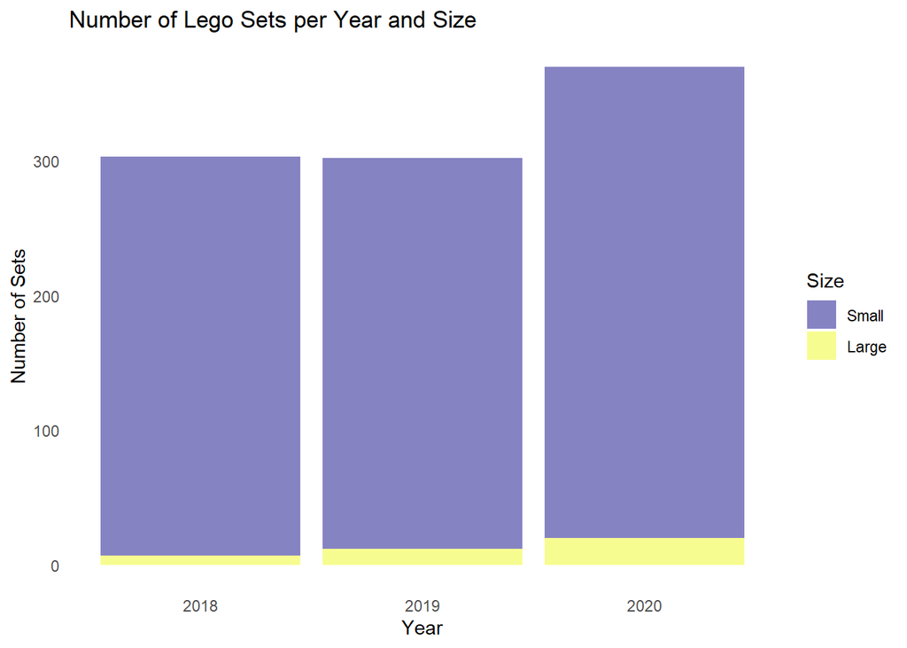

```r
sets_per_year_size <- lego_data %>%
  group_by(Year, Size) %>%
  summarize(count = n(), .groups = 'drop') %>%
  arrange(Year, desc(count))


sets_per_year_size <- sets_per_year_size %>%
  group_by(Year) %>%
  mutate(Size = fct_reorder(Size, count, .desc = TRUE)) %>%
  ungroup()


ggplot(sets_per_year_size, aes(x = Year, y = count, fill = Size)) +
  geom_bar(stat = "identity", position = "stack") +
  labs(title = "Number of Lego Sets per Year and Size",
       x = "Year",
       y = "Number of Sets",
       fill = "Size") +
  scale_fill_viridis_d(alpha = 0.5,
                       option = "plasma") +
  theme_minimal() +
  theme(
    panel.grid.major = element_blank(),
    panel.grid.minor = element_blank()
  )
```

### 3.2. Lego sets per availability.

Most of the Lego sets were sold on retail stores, with the highest numbers in 2020. However, **Lego exclusive** did see a constant increase during the three years.

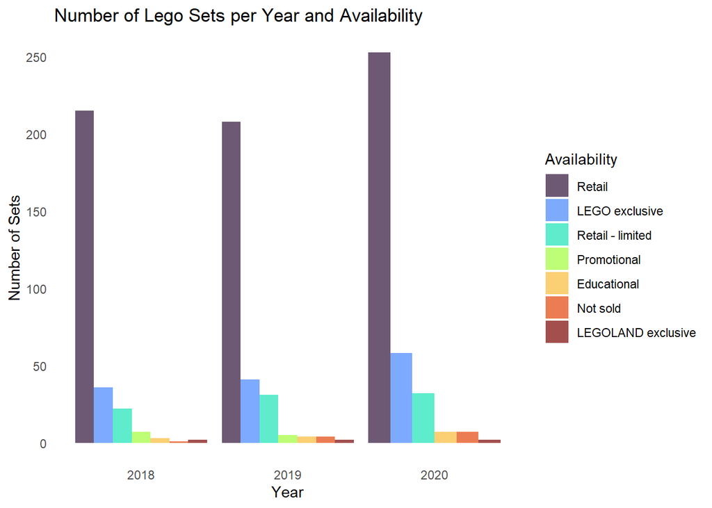

```r
sets_per_year_availability <- lego_data %>%
  filter(!is.na(Availability)) %>%
  group_by(Year, Availability) %>%
  summarize(count = n(), .groups = 'drop')%>%
  arrange(desc(count))%>%
  mutate(Availability = factor(Availability, levels = unique(Availability)))

ggplot(sets_per_year_availability, aes(x = Year, y = count, fill = Availability)) +
  geom_bar(stat = "identity", position = "dodge") +
  labs(title = "Number of Lego Sets per Year and Availability",
       x = "Year",
       y = "Number of Sets",
       fill = "Availability") +
  scale_fill_viridis_d(alpha = 0.7,
                       option = "turbo") +
  theme_minimal() +
  theme(
    panel.grid.major = element_blank(),
    panel.grid.minor = element_blank()
  )
```

### 3.3. Lego sets per packaging.

The **box** is the most used packaging type, with an 86% presence around the dataset.

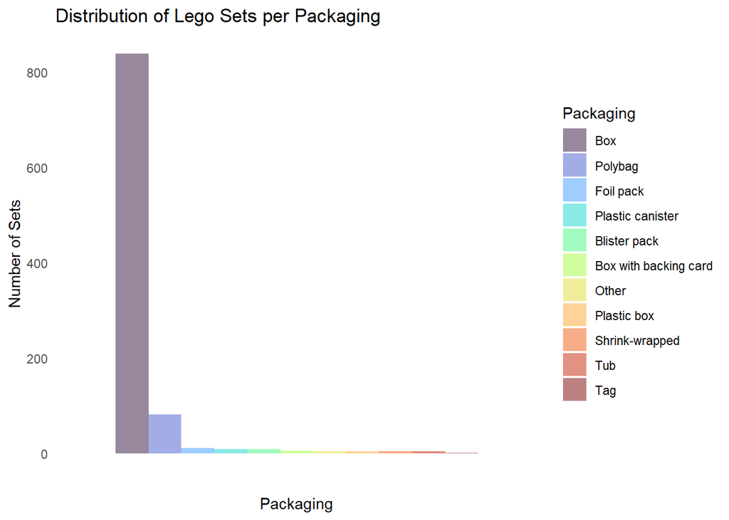

```r
sets_per_packaging <- lego_data %>%
  filter(!is.na(Packaging)) %>%
  group_by(Packaging) %>%
  summarize(count = n(), .groups = 'drop')%>%
  arrange(desc(count))%>%
  mutate(Packaging = factor(Packaging, levels = Packaging))

ggplot(sets_per_packaging, aes(x = "", y = count, fill = Packaging)) +
  geom_bar(stat = "identity", position = "dodge") +
  labs(title = "Distribution of Lego Sets per Packaging",
       x = "Packaging",
       y = "Number of Sets",
       fill = "Packaging") +
  scale_fill_viridis_d(alpha = 0.5,
                       option = "turbo") +
  theme_minimal() +
  theme(panel.grid.major = element_blank(),
        panel.grid.minor = element_blank())
```

### 3.4. Lego sets by year and packaging.

Just like in the first graph representing the amount of Lego sets and their size, the **box** packaging type saw and increase in 2020 in comparison to the previous years. In that same year, other types of packaging like **tag**, **plastic canister** and **box with backing card** appeared as packaging alternatives. Interestingly, the use of **polybag** on Lego sets decreased each year.

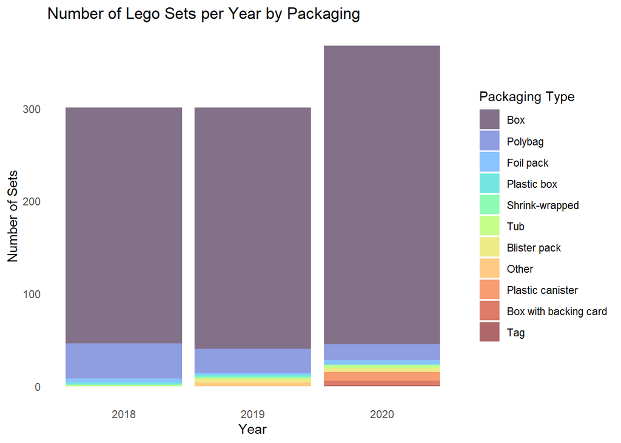

```r
sets_per_year_packaging <- lego_data %>%
  filter(!is.na(Packaging)) %>%
  group_by(Year, Packaging) %>%
  summarize(count = n(), .groups = 'drop') %>%
  arrange(Year, count)


sets_per_year_packaging <- sets_per_year_packaging %>%
  group_by(Year) %>%
  mutate(Packaging = fct_reorder(Packaging, count, .desc = TRUE)) %>%
  ungroup()


ggplot(sets_per_year_packaging, aes(x = Year, y = count, fill = Packaging)) +
  geom_bar(stat = "identity", position = "stack") +
  labs(title = "Number of Lego Sets per Year by Packaging",
       x = "Year",
       y = "Number of Sets",
       fill = "Packaging Type") +
  scale_fill_viridis_d(alpha = 0.6,
                       option = "turbo") +
  theme_minimal() +
  theme(
    panel.grid.major = element_blank(),
    panel.grid.minor = element_blank()
  )
```

### 3.5. Histogram functions for unique pieces, pieces, weight (kg) and minifigures.

These histograms aimed to have a closer inspection in behavioral changes along different variables concerning the Lego sets. While all variables are skewed positively, these variables behaved similar through every year.

As noticed from previous figures, total Lego sets increased during 2020. How did that increase affect the Lego sets? A proportional increase in the distribution of **unique pieces**, **pieces** and **minifigures** during that year can be seen in the variables’ graphs. This explains why the **weight** had a considerable (and proportional) increase in its count in the values around the mode.

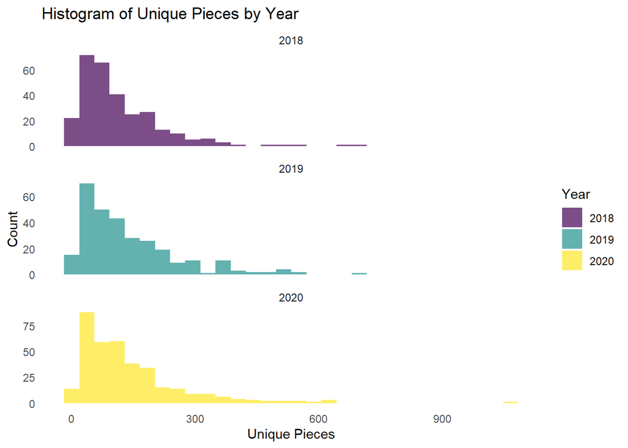

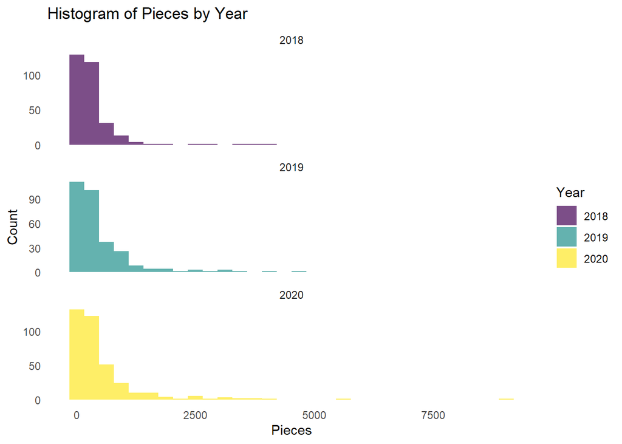

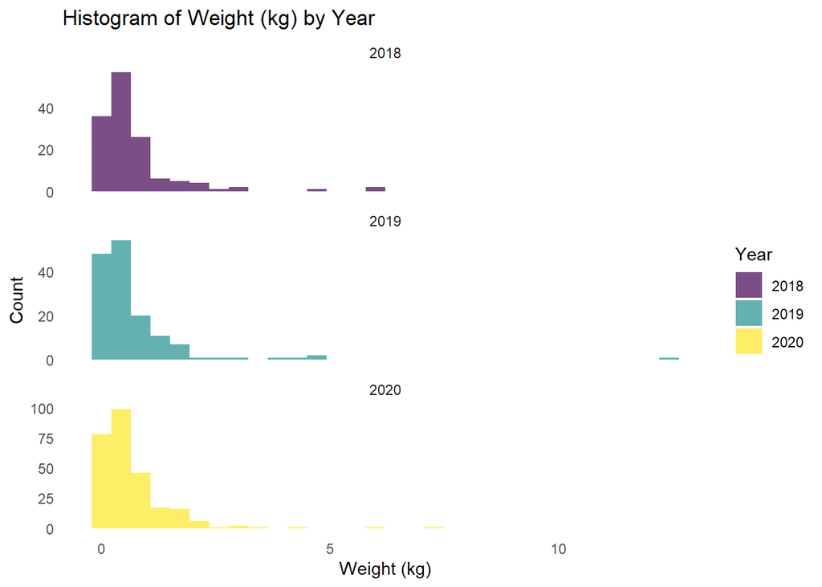

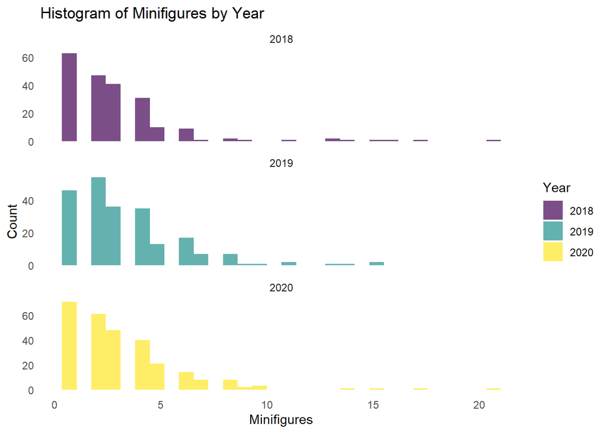

```r
variables_to_plot <- c("unique_pieces", "Pieces", "Weight_kg", "Minifigures")

variable_titles <- c(
  unique_pieces = "Unique Pieces",
  Pieces = "Pieces",
  Weight_kg = "Weight (kg)",
  Minifigures = "Minifigures"
)

plots <- list()

for (var in variables_to_plot) {
  plots[[var]] <- ggplot(lego_data %>% filter(!is.na(get(var)), !is.na(Year)), aes_string(x = var)) +
    geom_histogram(aes(fill = factor(Year)), alpha = 0.7, bins = 30, position = "identity") +
    labs(
      title = paste("Histogram of", variable_titles[[var]], "by Year"),
      x = variable_titles[[var]],
      y = "Count",
      fill = "Year"
    ) +
    scale_fill_viridis_d(alpha = 0.7) +
    theme_minimal() +
    theme(
      panel.grid.major = element_blank(),
      panel.grid.minor = element_blank()
    ) +
    facet_wrap(~ Year, ncol = 1, scales = "free_y")
}

for (var in variables_to_plot) {
  print(plots[[var]])
}
```

### 3.6. Lego sets correlation between pieces and weight.

**Pieces** and **weight** of Lego sets correlate positively, but the r-squared value of 0.639 shows a somewhat poor correlation.

*Note:* Both axes are set in logarithmic scales.

```r
model1 <- lm(log10(Weight_kg) ~ log10(Pieces), data = lego_data)
r2_1 <- summary(model1)$r.squared
print(paste("R^2 for Pieces vs Weight:", r2_1))
```

```
## [1] "R^2 for Pieces vs Weight: 0.638980997678262"
```

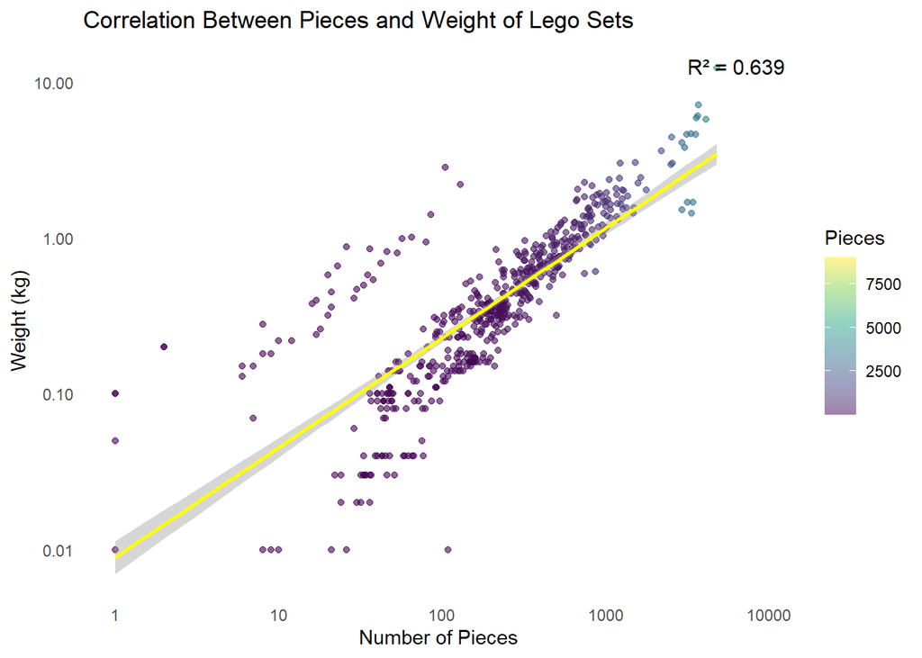

```r
ggplot(lego_data, aes(x = Pieces, y = Weight_kg, color = Pieces)) +
  geom_point(alpha = 0.6) +
  geom_smooth(method = "lm", color = "yellow", se = TRUE) +
  labs(
    title = "Correlation Between Pieces and Weight of Lego Sets",
    x = "Number of Pieces",
    y = "Weight (kg)"
  ) +
  scale_x_log10() +
  scale_y_log10() +
  scale_color_viridis_c(alpha = 0.5) +
  theme_minimal() +
  theme(
    panel.grid.major = element_blank(),
    panel.grid.minor = element_blank()
  ) +
  annotate("text", x = Inf, y = Inf, label = paste("R² =", round(r2_1, 3)),
           hjust = 1.1, vjust = 2, size = 4, color = "black")
```

### 3.7. Lego sets correlation between unique pieces and pieces.

While maybe **unique pieces** may seem as a replacement for **pieces**, the data shows that an increase in **pieces** also means in increment in **unique pieces** (evidence of that is the strong correlation showed by the r-squared value of 0.844). A possible explanation to this is that **unique pieces** might depend from normal **pieces** in order to construct the Lego set.

Another explanation could be that they could be they are independent from each other and they just gather a positive correlation without a logical explanation.

However, we could conclude from this data that, if **unique pieces** served as a substitute for **pieces**, they would not correlate positively. If it was the case, Lego sets with higher amounts of **unique pieces** would have a considerable decrease in the number of **pieces**.

*Note*: Both axes are set in logarithmic scales.

```r
model2 <- lm(log10(unique_pieces) ~ log10(Pieces), data = lego_data)
r2_2 <- summary(model2)$r.squared
print(paste("R^2 for Pieces vs Unique Pieces:", r2_2))
```

```
## [1] "R^2 for Pieces vs Unique Pieces: 0.84367087682854"
```

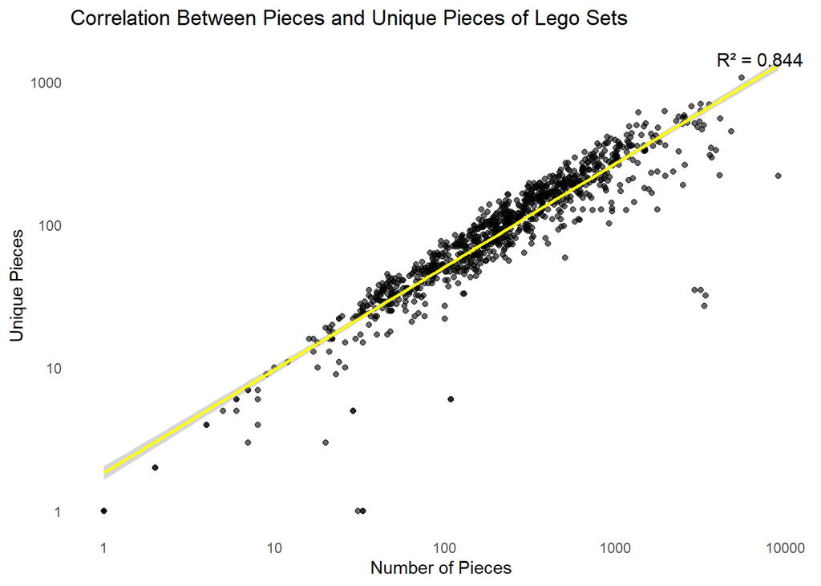

```r
ggplot(lego_data, aes(x = Pieces, y = unique_pieces)) +
  geom_point(alpha = 0.6) +
  geom_smooth(method = "lm", color = "yellow", se = TRUE) +
  labs(
    title = "Correlation Between Pieces and Unique Pieces of Lego Sets",
    x = "Number of Pieces",
    y = "Unique Pieces"
  ) +
  scale_x_log10() +
  scale_y_log10() +
  scale_colour_viridis_c(alpha = 0.5) +
  theme_minimal() +
  theme(
    panel.grid.major = element_blank(),
    panel.grid.minor = element_blank()
  ) +
  annotate("text", x = Inf, y = Inf, label = paste("R² =", round(r2_2, 3)),
           hjust = 1.1, vjust = 2, size = 4, color = "black")
```

### 3.8. Lego sets correlation between unique pieces and weight.

A positive correlation between **unique pieces** and **weight** can also be found, but the r-squared value is a low 0.56. Notice how as **unique pieces** increase, the **weight** also increases (not the case at lower values).

*Note:* Both axes are set in logarithmic scale.

```r
model3 <- lm(log10(Weight_kg) ~ log10(unique_pieces), data = lego_data)
r2_3 <- summary(model3)$r.squared
print(paste("R^2 for Unique Pieces vs Weight:", r2_3))
```

```
## [1] "R^2 for Unique Pieces vs Weight: 0.560243709619204"
```

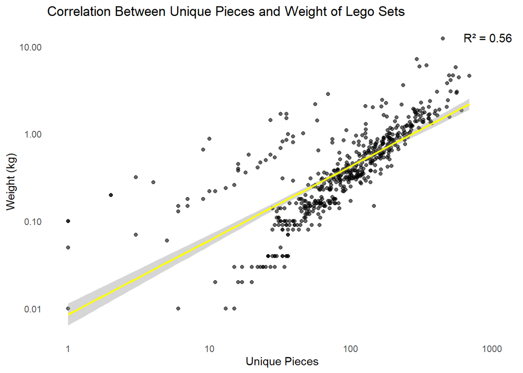

```r
ggplot(lego_data, aes(x = unique_pieces, y = Weight_kg)) +
  geom_point(alpha = 0.6) +
  geom_smooth(method = "lm", color = "yellow", se = TRUE) +
  labs(
    title = "Correlation Between Unique Pieces and Weight of Lego Sets",
    x = "Unique Pieces",
    y = "Weight (kg)"
  ) +
  scale_x_log10() +
  scale_y_log10() +
  scale_colour_viridis_c(alpha = 0.5) +
  theme_minimal() +
  theme(
    panel.grid.major = element_blank(),
    panel.grid.minor = element_blank()
  ) +
  annotate("text", x = Inf, y = Inf, label = paste("R² =", round(r2_3, 3)),
           hjust = 1.1, vjust = 2, size = 4, color = "black")
```

### 3.9. Lego sets correlation between minifigures and pieces

Although still positive, even less steep is the relationship between **minifigures** and **pieces**. The r-squared value is the poorest from all correlations, meaning increases in **minifigures** do not explain well increases in **pieces**.

```r
model4 <- lm(Pieces ~ Minifigures, data = lego_data)
r2_4 <- summary(model4)$r.squared
print(paste("R^2 for Minifigures vs Pieces:", r2_4))
```

```
## [1] "R^2 for Minifigures vs Pieces: 0.309165478910522"
```

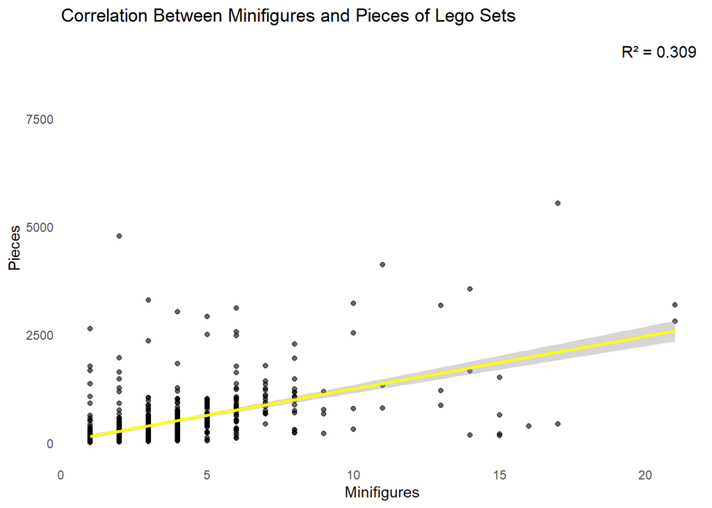

```r
ggplot(lego_data, aes(x = Minifigures, y = Pieces)) +
  geom_point(alpha = 0.6) +
  geom_smooth(method = "lm", color = "yellow", se = TRUE) +
  labs(
    title = "Correlation Between Minifigures and Pieces of Lego Sets",
    x = "Minifigures",
    y = "Pieces"
  ) +
  scale_colour_viridis_c(alpha = 0.5) +
  theme_minimal() +
  theme(
    panel.grid.major = element_blank(),
    panel.grid.minor = element_blank()
  ) +
  annotate("text", x = Inf, y = Inf, label = paste("R² =", round(r2_4, 3)),
           hjust = 1.1, vjust = 2, size = 4, color = "black")
```

### 3.10. Lego sets correlation between minifigures and unique pieces

While similar to the last graph, **minifigures** and **unique pieces** regression starts from a higher standpoint. Again, **minifigures** does not seem to predict very well an increase in **unique pieces** (r-squared value of 0.46).

```r
model5 <- lm(unique_pieces ~ Minifigures, data = lego_data)
r2_5 <- summary(model5)$r.squared
print(paste("R^2 for Minifigures vs Unique Pieces:", r2_5))
```

```
## [1] "R^2 for Minifigures vs Unique Pieces: 0.460427163130205"
```

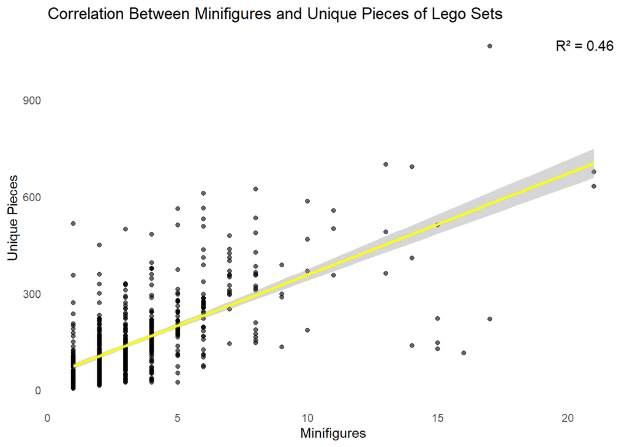

```r
ggplot(lego_data, aes(x = Minifigures, y = unique_pieces)) +
  geom_point(alpha = 0.6) +
  geom_smooth(method = "lm", color = "yellow", se = TRUE) +
  labs(
    title = "Correlation Between Minifigures and Unique Pieces of Lego Sets",
    x = "Minifigures",
    y = "Unique Pieces"
  ) +
  scale_colour_viridis_c(alpha = 0.5) +
  theme_minimal() +
  theme(
    panel.grid.major = element_blank(),
    panel.grid.minor = element_blank()
  ) +
  annotate("text", x = Inf, y = Inf, label = paste("R² =", round(r2_5, 3)),
           hjust = 1.1, vjust = 2, size = 4, color = "black")
```

### 3.11. Lego sets per age group (LegoKids, LegoTeens and LegoAdults).

Since the amount of **age groups** makes it difficult to interpret the data, we created a new variable called *LowerAge*, where lower values of **age groups** were extracted (since some of the them had age intervals). The idea was to classify the Lego sets in three new different **age groups**:

1. LegoKids: LowerAge =< 10
2. LegoTeens: 10 < LowerAge >= 17
3. LegoAdults: LowerAge >= 18

We can clearly see the **LegoKids** sets amount for the vast majority of the Lego sets, with a 92,7% overall.

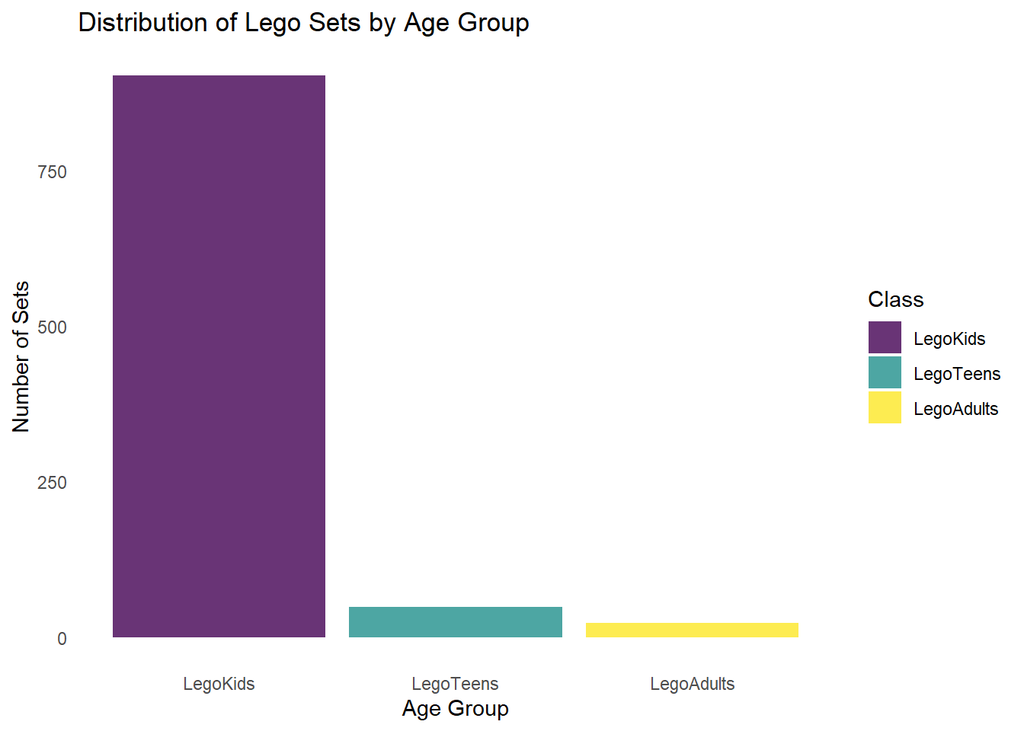

```r
class_counts <- lego_data %>%
  summarize(
    LegoKids = sum(LegoKids, na.rm = TRUE),
    LegoTeens = sum(LegoTeens, na.rm = TRUE),
    LegoAdults = sum(LegoAdults, na.rm = TRUE)
  ) %>%
  pivot_longer(cols = everything(), names_to = "Class", values_to = "Count") %>%
  mutate(Class = factor(Class, levels = c("LegoKids", "LegoTeens", "LegoAdults")))


ggplot(class_counts, aes(x = Class, y = Count, fill = Class)) +
  geom_bar(stat = "identity") +
  labs(
    title = "Distribution of Lego Sets by Age Group",
    x = "Age Group",
    y = "Number of Sets"
  ) +
  scale_fill_viridis_d(alpha = 0.8) +
  theme_minimal() +
  theme(
    panel.grid.major = element_blank(),
    panel.grid.minor = element_blank()
  )
```

### 3.12. Top 10 Lego themes by the amount of Lego sets.

While **City** is the only theme to surpass the 100 sets line, **Friends** and **Star Wars** are tied for second place.

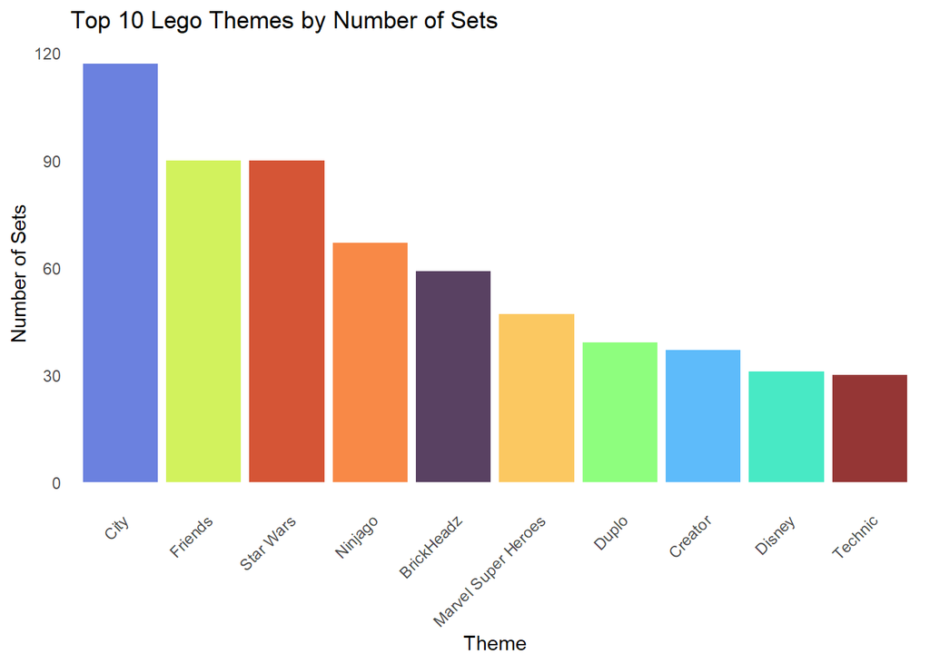

```r
sets_per_theme <- lego_data %>%
  filter(!is.na(Theme)) %>%
  group_by(Theme) %>%
  summarize(count = n(), .groups = 'drop') %>%
  arrange(desc(count)) %>%
  slice_head(n = 10)


ggplot(sets_per_theme, aes(x = reorder(Theme, -count), y = count, fill = Theme)) +
  geom_bar(stat = "identity") +
  labs(title = "Top 10 Lego Themes by Number of Sets",
       x = "Theme",
       y = "Number of Sets") +
  theme_minimal() +
  scale_fill_viridis_d(alpha = 0.8,
                       option = "turbo") +
  theme(
    panel.grid.major = element_blank(),
    panel.grid.minor = element_blank(),
    axis.text.x = element_text(angle = 45, hjust = 1),
    legend.position = "none"
  )
```

### 3.13. Evolution year by year of Lego sets within the top 10 themes.

A couple of interesting cases when it comes to the year by year evolution Lego sets in the top 10 themes:

1. **Friends** had an important decrease in the number of sets in 2019, just to skyrocket its numbers in 2020.
2. **Ninjago** and **Duplo** had constant increases each year.
3. Technic hit a plateau in the last two years.

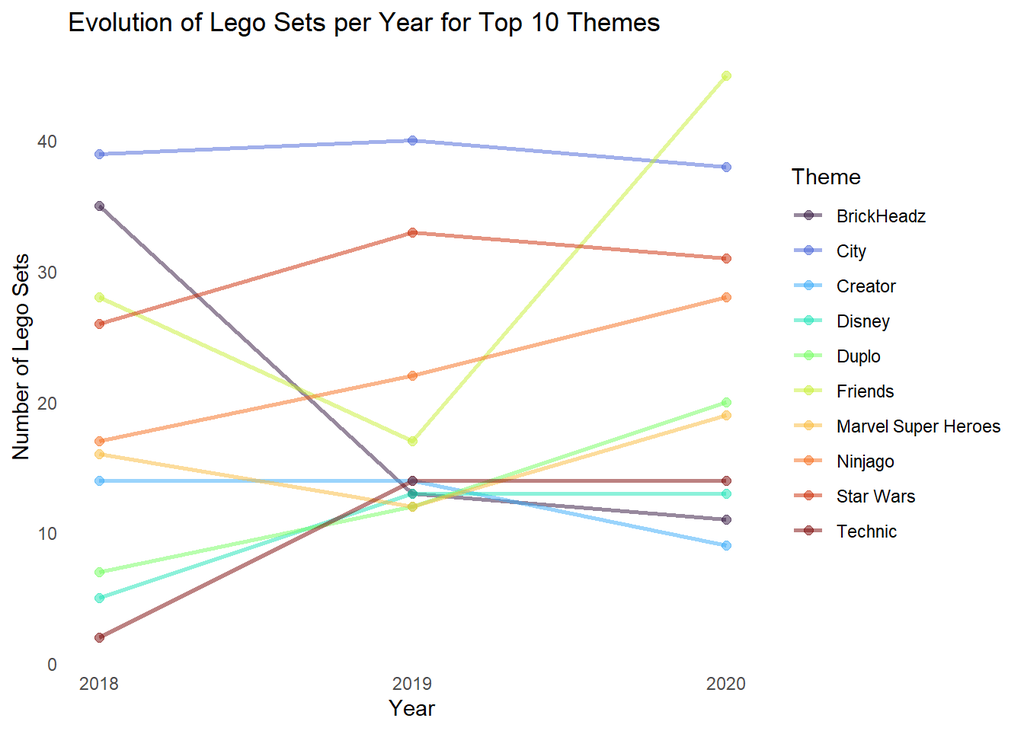

```r
top_themes <- lego_data %>%
  count(Theme, sort = TRUE) %>%
  slice_max(n, n = 10) %>%
  pull(Theme)


sets_per_year_theme <- lego_data %>%
  filter(Theme %in% top_themes) %>%
  group_by(Year, Theme) %>%
  summarize(count = n(), .groups = 'drop')


ggplot(sets_per_year_theme, aes(x = Year, y = count, color = Theme)) +
  geom_line(size = 1) +
  geom_point(size = 2) +
  scale_x_continuous(breaks = seq(min(sets_per_year_theme$Year), max(sets_per_year_theme$Year), by = 1)) +
  labs(
    title = "Evolution of Lego Sets per Year for Top 10 Themes",
    x = "Year",
    y = "Number of Lego Sets",
    color = "Theme"
  ) +
  scale_colour_viridis_d(alpha = 0.5,
                         option = "turbo") +
  theme_minimal() +
  theme(
    panel.grid.major = element_blank(),
    panel.grid.minor = element_blank(),
    legend.position = "right"
  )
```

### 3.14. Lego sets by top 10 themes and age group.

Returning to the new age groups classification, we can see most of the top 10 themes only offer sets within the **LegoKids** age classification. Star Wars is the theme with most representation in the **LegoTeens** and **LegoAdults** age groups in the top 10 themes.

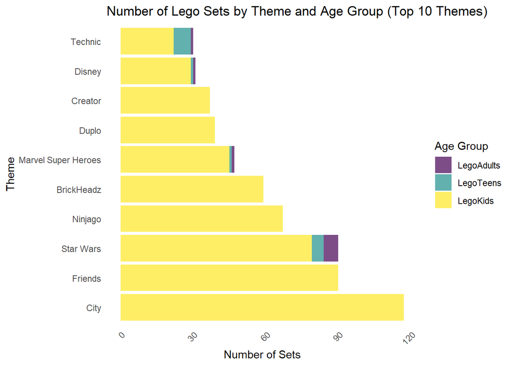

```r
top_themes <- lego_data %>%
  mutate(total_count = LegoKids + LegoTeens + LegoAdults) %>%
  group_by(Theme) %>%
  summarize(total_count = sum(total_count), .groups = 'drop') %>%
  arrange(desc(total_count)) %>%
  head(10) %>%
  pull(Theme)


theme_age_group_counts <- lego_data %>%
  filter(Theme %in% top_themes) %>%
  pivot_longer(cols = c(LegoKids, LegoTeens, LegoAdults),
               names_to = "AgeGroup", values_to = "Flag") %>%
  filter(Flag == 1) %>%
  group_by(Theme, AgeGroup) %>%
  summarize(count = n(), .groups = 'drop') %>%
  mutate(
    Theme = factor(Theme, levels = top_themes),
    AgeGroup = factor(AgeGroup, levels = c("LegoAdults", "LegoTeens", "LegoKids"))
  )


ggplot(theme_age_group_counts, aes(x = Theme, y = count, fill = AgeGroup)) +
  geom_bar(stat = "identity") +
  labs(title = "Number of Lego Sets by Theme and Age Group (Top 10 Themes)",
       x = "Theme",
       y = "Number of Sets",
       fill = "Age Group") +
  scale_fill_viridis_d(alpha = 0.7) +
  theme_minimal() +
  theme(
    axis.text.x = element_text(angle = 45, hjust = 1),
    panel.grid.major = element_blank(),
    panel.grid.minor = element_blank()
  ) +
  coord_flip()
```

### 3.15. Distribution of pieces across the three age groups.

**LegoKids** age group has the narrowest distribution, which serves a logic as more pieces relate to more complex Lego sets. However, we can see many outliers in this age group.

**LegoTeens** and **LegoAdults** have wider distributions and higher boxplots than LegoKids.

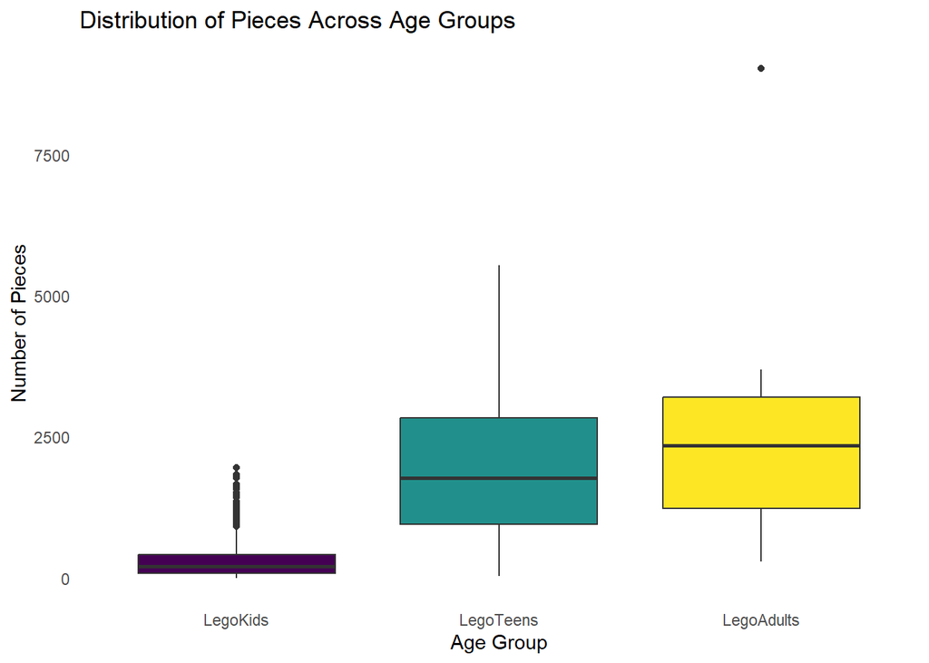

```r
age_group_data <- lego_data %>%
  select(Pieces, LegoKids, LegoTeens, LegoAdults) %>%
  pivot_longer(cols = c(LegoKids, LegoTeens, LegoAdults), names_to = "AgeGroup", values_to = "Flag") %>%
  filter(Flag == 1)

age_group_data$AgeGroup <- factor(age_group_data$AgeGroup, levels = c("LegoKids", "LegoTeens", "LegoAdults"))

ggplot(age_group_data, aes(x = AgeGroup, y = Pieces, fill = AgeGroup)) +
  geom_boxplot() +
  scale_fill_viridis_d() +
  labs(
    title = "Distribution of Pieces Across Age Groups",
    x = "Age Group",
    y = "Number of Pieces"
  ) +
  theme_minimal() +
  theme(
    panel.grid.major = element_blank(),
    panel.grid.minor = element_blank(),
    legend.position = "none"
  )
```

### 3.16. Distribution of unique pieces across the three age groups.

**LegoKids** age group still has the narrowest distribution and presents the most amount of outliers.

Surprisingly, **LegoTeens** presents a broader spectrum for unique pieces compared to **LegoAdults**. Both present positive skewness.

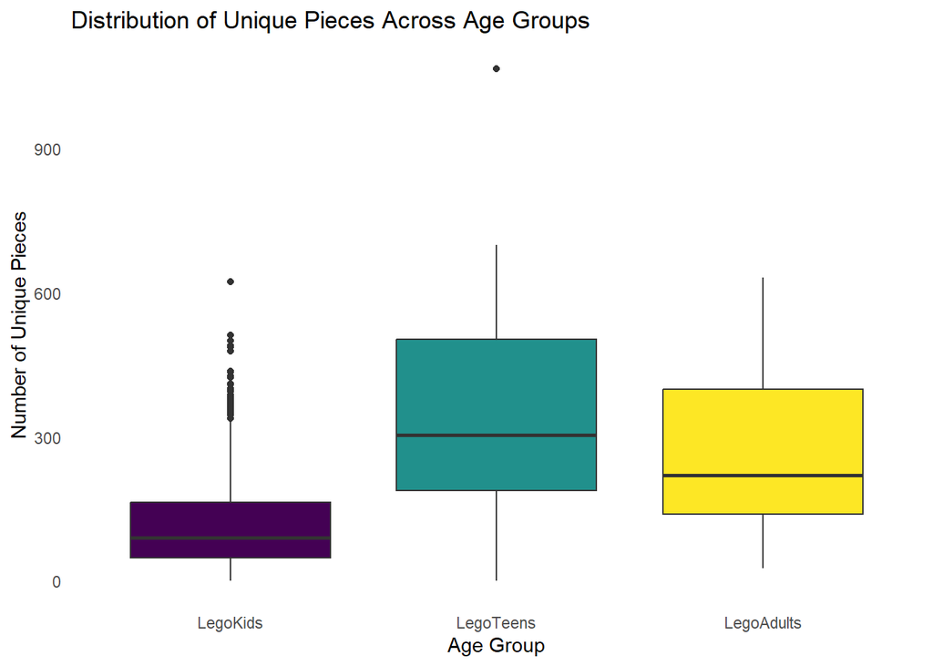

```r
age_group_data <- lego_data %>%
  select(unique_pieces, LegoKids, LegoTeens, LegoAdults) %>%
  pivot_longer(cols = c(LegoKids, LegoTeens, LegoAdults), names_to = "AgeGroup", values_to = "Flag") %>%
  filter(Flag == 1)


age_group_data$AgeGroup <- factor(age_group_data$AgeGroup, levels = c("LegoKids", "LegoTeens", "LegoAdults"))


ggplot(age_group_data, aes(x = AgeGroup, y = unique_pieces, fill = AgeGroup)) +
  geom_boxplot() +
  scale_fill_viridis_d() +
  labs(
    title = "Distribution of Unique Pieces Across Age Groups",
    x = "Age Group",
    y = "Number of Unique Pieces"
  ) +
  theme_minimal() +
  theme(
    panel.grid.major = element_blank(),
    panel.grid.minor = element_blank(),
    legend.position = "none"
  )
```

### 3.17. Distribution of minifigures across the three age groups.

Once again, **LegoKids** age group has the narrowest distribution and presents the most amount of outliers.

**LegoTeens** remains ahead of **LegoAdults**. Both present positive skewness in their distributions, with **LegoAdults** case being more steep descending.

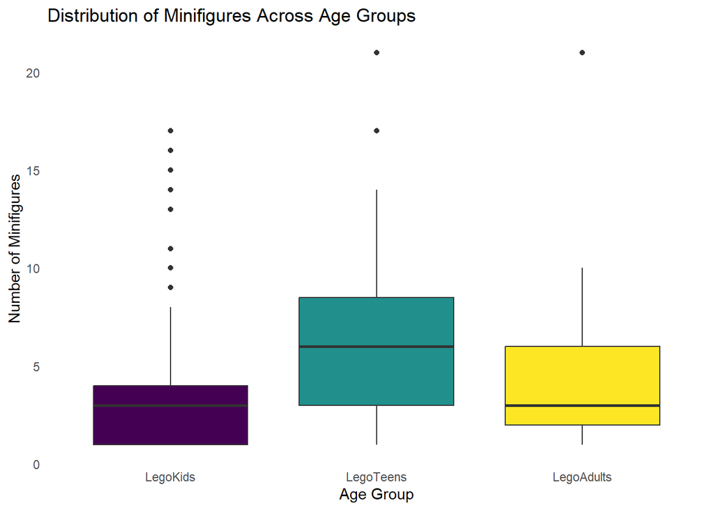

```r
age_group_data <- lego_data %>%
  select(Minifigures, LegoKids, LegoTeens, LegoAdults) %>%
  pivot_longer(cols = c(LegoKids, LegoTeens, LegoAdults), names_to = "AgeGroup", values_to = "Flag") %>%
  filter(Flag == 1)


age_group_data$AgeGroup <- factor(age_group_data$AgeGroup, levels = c("LegoKids", "LegoTeens", "LegoAdults"))


ggplot(age_group_data, aes(x = AgeGroup, y = Minifigures, fill = AgeGroup)) +
  geom_boxplot() +
  scale_fill_viridis_d() +
  labs(
    title = "Distribution of Minifigures Across Age Groups",
    x = "Age Group",
    y = "Number of Minifigures"
  ) +
  theme_minimal() +
  theme(
    panel.grid.major = element_blank(),
    panel.grid.minor = element_blank(),
    legend.position = "none"
  )
```

### 3.18. Pieces, unique pieces and minifigures count by theme (top 10 themes)

Notice the following cases:

1. **City** sets amount the highest values in **unique pieces** and **minifigures**.
2. Despite being in tied-second place, **Star Wars** amounts the highest value in **pieces**, followed by **Technic** (which means that theme offers a higher volume of **pieces** per set than most of the other themes, despite being the last theme in the top 10).
3. **BrickHeadz** and **Technic** sets do not include **minifigures**, the reason being these sets` themes do not have a place for **minifigures**.

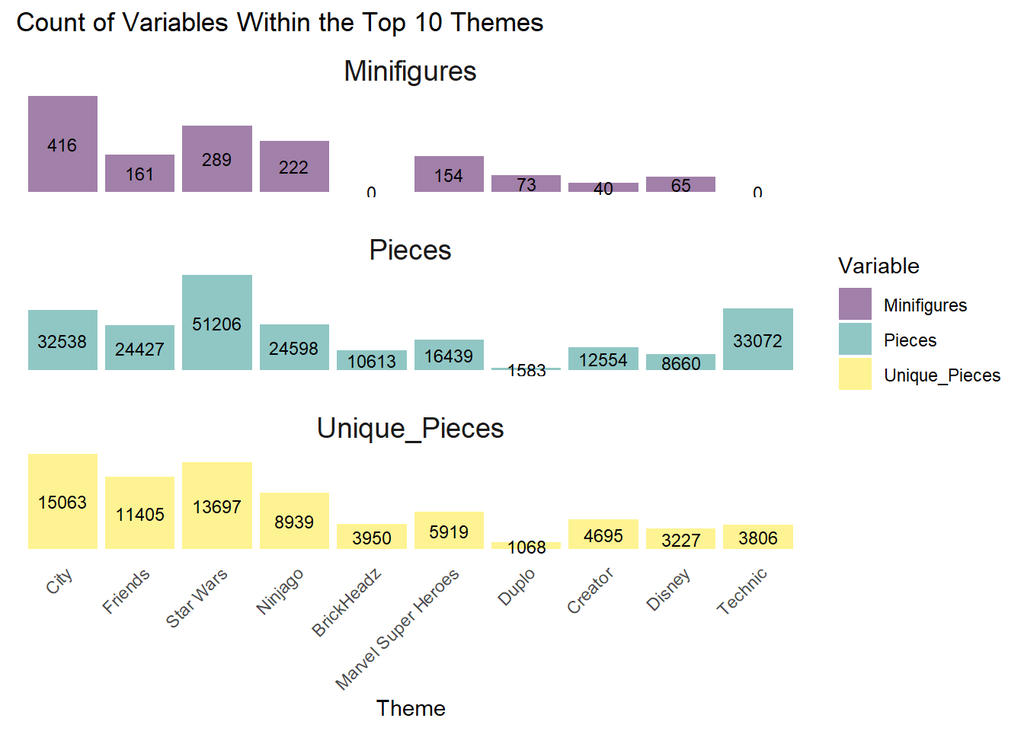

```r
top_themes <- lego_data %>%
  count(Theme, sort = TRUE) %>%
  slice_max(n, n = 10) %>%
  pull(Theme)


summary_data <- lego_data %>%
  filter(Theme %in% top_themes) %>%
  group_by(Theme) %>%
  summarize(
    Pieces = sum(Pieces, na.rm = TRUE),
    Unique_Pieces = sum(unique_pieces, na.rm = TRUE),
    Minifigures = sum(Minifigures, na.rm = TRUE),
    .groups = 'drop'
  )


summary_long <- summary_data %>%
  pivot_longer(cols = c(Pieces, Unique_Pieces, Minifigures),
               names_to = "Variable",
               values_to = "Count") %>%
  mutate(Theme = factor(Theme, levels = top_themes))


ggplot(summary_long, aes(x = Theme, y = Count, fill = Variable)) +
  geom_bar(stat = "identity", position = "stack") +
  geom_text(aes(label = Count), position = position_stack(vjust = 0.5), size = 3) +
  facet_wrap(~ Variable, scales = "free_y", ncol = 1) +
  labs(title = "Count of Variables Within the Top 10 Themes",
       x = "Theme",
       y = NULL,
       fill = "Variable") +
  scale_fill_viridis_d(alpha = 0.5) +
  theme_minimal() +
  theme(axis.text.x = element_text(angle = 45, hjust = 1),
        strip.text = element_text(size = 14),
        panel.spacing = unit(1, "lines"),
        panel.grid = element_blank(),
        axis.title.y = element_blank(),
        axis.text.y = element_blank(),
        axis.ticks.y = element_blank())
```

### 3.19. Top 10 themes: total sets and average pieces per set.

Since last graph has interesting cases regarding variables such as **pieces**, we can compare the total amount of sets of the top 10 **themes** with the **average pieces per set per theme**. This will allow us to visualize which themes have higher amounts of pieces per set.

Surprisingly, **Technic** appears in both extremes in the two graphs. It is the last theme by the amount of total sets but the first in terms of average **pieces** per set per theme. **Star Wars** on the other hand shares second place in both graphs. Interestingly, **Duplo** offers the least average **pieces** per set while not being the last in terms of total sets.

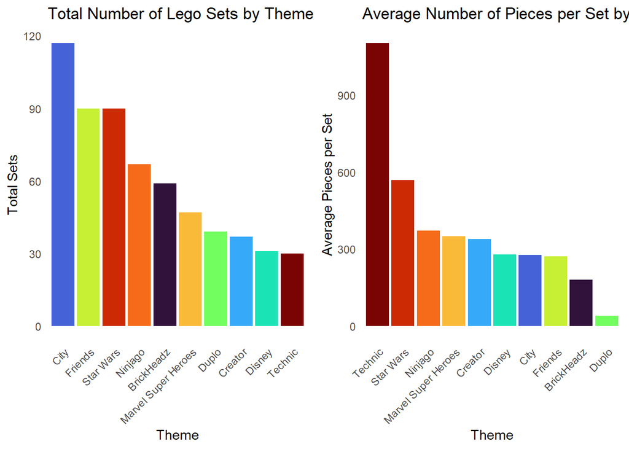

```r
top_themes <- lego_data %>%
  count(Theme, sort = TRUE) %>%
  top_n(10, n) %>%
  pull(Theme)


top_theme_data <- lego_data %>%
  filter(Theme %in% top_themes)


sets_per_theme <- top_theme_data %>%
  group_by(Theme) %>%
  summarize(total_sets = n(), .groups = 'drop')


avg_pieces_per_theme <- top_theme_data %>%
  group_by(Theme) %>%
  summarize(avg_pieces = mean(Pieces, na.rm = TRUE), .groups = 'drop')


plot_total_sets <- ggplot(sets_per_theme, aes(x = reorder(Theme, -total_sets), y = total_sets, fill = Theme)) +
  geom_bar(stat = "identity") +
  scale_fill_viridis_d(option = "turbo") +
  labs(title = "Total Number of Lego Sets by Theme", x = "Theme", y = "Total Sets") +
  theme_minimal() +
  theme(
    axis.text.x = element_text(angle = 45, hjust = 1),
    legend.position = "none",
    panel.grid.major = element_blank(),
    panel.grid.minor = element_blank()
  )


plot_avg_pieces <- ggplot(avg_pieces_per_theme, aes(x = reorder(Theme, -avg_pieces), y = avg_pieces, fill = Theme)) +
  geom_bar(stat = "identity") +
  scale_fill_viridis_d(option = "turbo") +
  labs(title = "Average Number of Pieces per Set by Theme", x = "Theme", y = "Average Pieces per Set") +
  theme_minimal() +
  theme(
    axis.text.x = element_text(angle = 45, hjust = 1),
    legend.position = "none",
    panel.grid.major = element_blank(),
    panel.grid.minor = element_blank()
  )


grid.arrange(plot_total_sets, plot_avg_pieces, ncol = 2)
```

### 3.20. Distribution with boxplots: Pieces across the top 10 themes.

**Technic** sets present the broadest distribution of **pieces**.

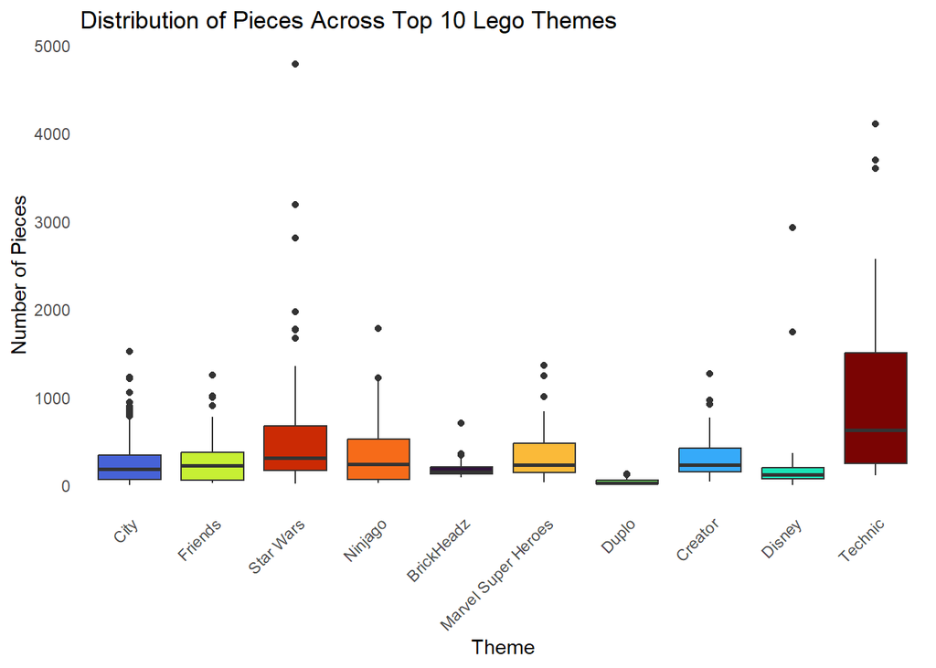

```r
top_themes <- lego_data %>%
  count(Theme, sort = TRUE) %>%
  top_n(10, n) %>%
  pull(Theme)


top_theme_data <- lego_data %>%
  filter(Theme %in% top_themes)


sets_per_theme <- top_theme_data %>%
  group_by(Theme) %>%
  summarize(total_sets = n())


top_theme_data <- top_theme_data %>%
  left_join(sets_per_theme, by = "Theme")


ggplot(top_theme_data, aes(x = reorder(Theme, -total_sets), y = Pieces, fill = Theme)) +
  geom_boxplot() +
  scale_fill_viridis_d(option = "turbo") +
  labs(
    title = "Distribution of Pieces Across Top 10 Lego Themes",
    x = "Theme",
    y = "Number of Pieces"
  ) +
  theme_minimal() +
  theme(
    axis.text.x = element_text(angle = 45, hjust = 1),
    panel.grid.major = element_blank(),
    panel.grid.minor = element_blank(),
    legend.position = "none"
  )
```

### 3.21. Top 10 themes: total sets and average unique pieces per set.

Most of the themes present similar **average unique pieces per set** per set. However, if you compare that to the total amount of **unique pieces** each theme amounts to, the results are very assymetric compared to this graph. The symmetric levels of **average unique pieces per set** can be explained as a result of descending levels of total sets per **theme** with asymmetric levels of **unique pieces** (in absolute terms).

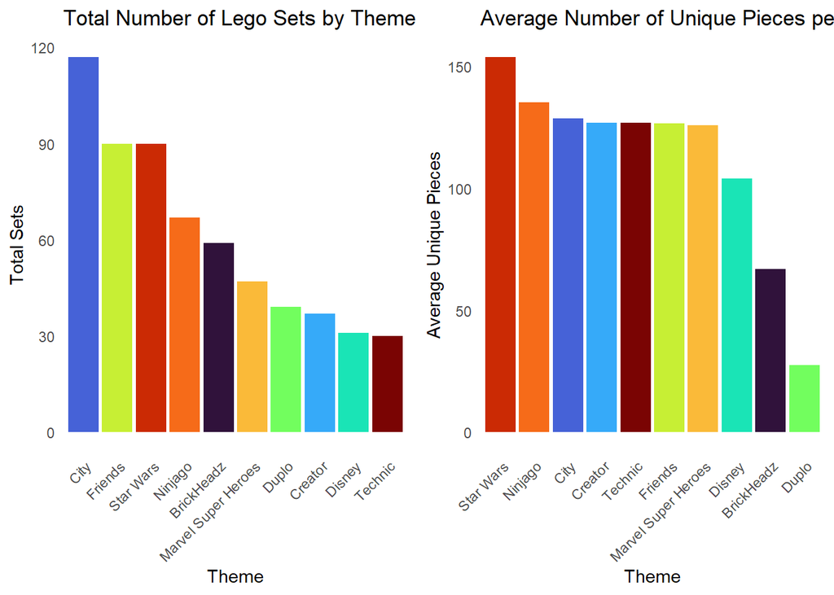

```r
top_themes <- lego_data %>%
  count(Theme, sort = TRUE) %>%
  top_n(10, n) %>%
  pull(Theme)


top_theme_data <- lego_data %>%
  filter(Theme %in% top_themes)


sets_per_theme <- top_theme_data %>%
  group_by(Theme) %>%
  summarize(total_sets = n(), .groups = 'drop')


avg_unique_pieces_per_theme <- top_theme_data %>%
  group_by(Theme) %>%
  summarize(avg_unique_pieces = mean(unique_pieces, na.rm = TRUE), .groups = 'drop')


plot_total_sets <- ggplot(sets_per_theme, aes(x = reorder(Theme, -total_sets), y = total_sets, fill = Theme)) +
  geom_bar(stat = "identity") +
  scale_fill_viridis_d(option = "turbo") +
  labs(title = "Total Number of Lego Sets by Theme", x = "Theme", y = "Total Sets") +
  theme_minimal() +
  theme(
    axis.text.x = element_text(angle = 45, hjust = 1),
    legend.position = "none",
    panel.grid.major = element_blank(),
    panel.grid.minor = element_blank()
  )


plot_avg_unique_pieces <- ggplot(avg_unique_pieces_per_theme, aes(x = reorder(Theme, -avg_unique_pieces), y = avg_unique_pieces, fill = Theme)) +
  geom_bar(stat = "identity") +
  scale_fill_viridis_d(option = "turbo") +
  labs(title = "Average Number of Unique Pieces pet Set by Theme", x = "Theme", y = "Average Unique Pieces") +
  theme_minimal() +
  theme(
    axis.text.x = element_text(angle = 45, hjust = 1),
    legend.position = "none",
    panel.grid.major = element_blank(),
    panel.grid.minor = element_blank()
  )


grid.arrange(plot_total_sets, plot_avg_unique_pieces, ncol = 2)
```

### 3.22. Distribution with boxplots: Unique pieces across the top 10 themes.

When it comes to **unique pieces**, the top 10 **themes** present similar distributions. **Brickheadz** and **Duplo** present the narrowest distributions. Again, **themes** might the reason why certain types of **pieces** are more or less present in Lego sets.

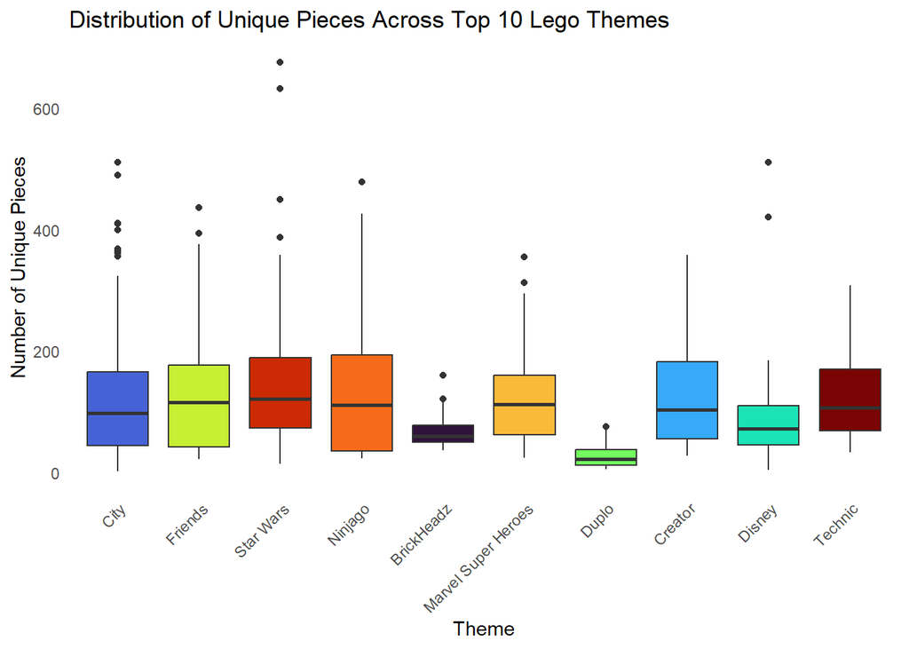

```r
top_themes <- lego_data %>%
  count(Theme, sort = TRUE) %>%
  top_n(10, n) %>%
  pull(Theme)


top_theme_data <- lego_data %>%
  filter(Theme %in% top_themes)


sets_per_theme <- top_theme_data %>%
  group_by(Theme) %>%
  summarize(total_sets = n())


top_theme_data <- top_theme_data %>%
  left_join(sets_per_theme, by = "Theme")


ggplot(top_theme_data, aes(x = reorder(Theme, -total_sets), y = unique_pieces, fill = Theme)) +
  geom_boxplot() +
  scale_fill_viridis_d(option = "turbo") +
  labs(
    title = "Distribution of Unique Pieces Across Top 10 Lego Themes",
    x = "Theme",
    y = "Number of Unique Pieces"
  ) +
  theme_minimal() +
  theme(
    axis.text.x = element_text(angle = 45, hjust = 1),
    panel.grid.major = element_blank(),
    panel.grid.minor = element_blank(),
    legend.position = "none"
  )
```

### 3.23. Top 10 themes: total sets and average minifigures per set.

**Average minifigures per set** are higher in **Star Wars** and **City** themes. **Marvel Super Heroes** is a special case, where while not being the one with most sets, it offers the third highest **average minifigures per set**.

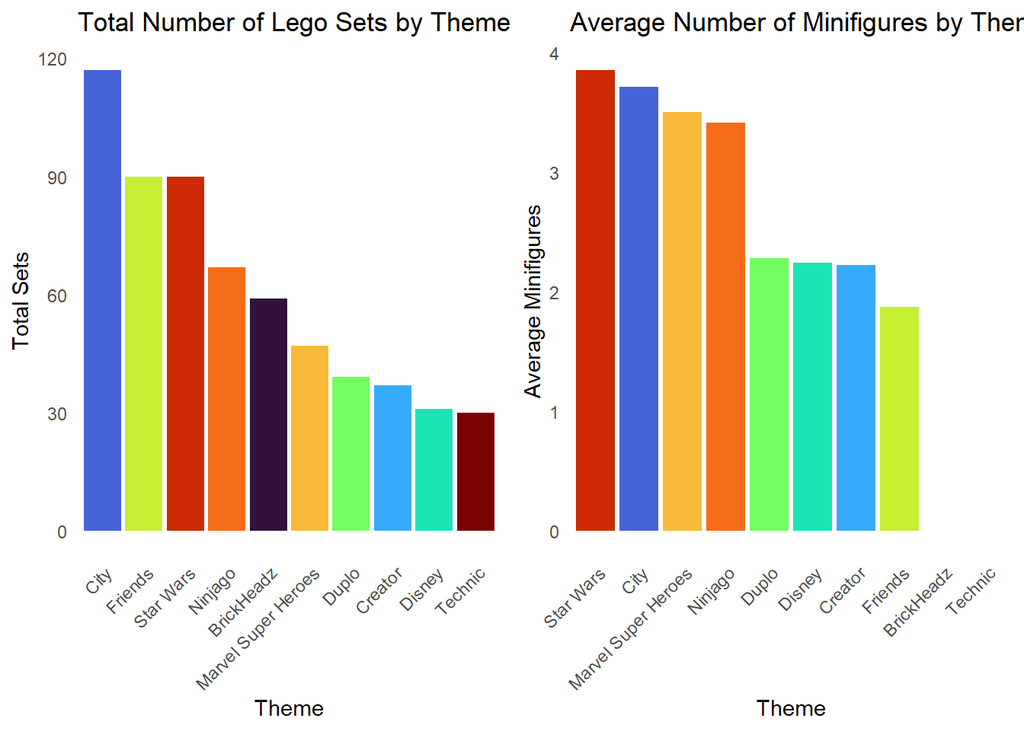

```r
top_themes <- lego_data %>%
  count(Theme, sort = TRUE) %>%
  top_n(10, n) %>%
  pull(Theme)


top_theme_data <- lego_data %>%
  filter(Theme %in% top_themes)


sets_per_theme <- top_theme_data %>%
  group_by(Theme) %>%
  summarize(total_sets = n(), .groups = 'drop')


avg_minifigures_per_theme <- top_theme_data %>%
  group_by(Theme) %>%
  summarize(avg_minifigures = mean(Minifigures, na.rm = TRUE), .groups = 'drop')


plot_total_sets <- ggplot(sets_per_theme, aes(x = reorder(Theme, -total_sets), y = total_sets, fill = Theme)) +
  geom_bar(stat = "identity") +
  scale_fill_viridis_d(option = "turbo") +
  labs(title = "Total Number of Lego Sets by Theme", x = "Theme", y = "Total Sets") +
  theme_minimal() +
  theme(
    axis.text.x = element_text(angle = 45, hjust = 1),
    legend.position = "none",
    panel.grid.major = element_blank(),
    panel.grid.minor = element_blank()
  )


plot_avg_minifigures <- ggplot(avg_minifigures_per_theme, aes(x = reorder(Theme, -avg_minifigures), y = avg_minifigures, fill = Theme)) +
  geom_bar(stat = "identity") +
  scale_fill_viridis_d(option = "turbo") +
  labs(title = "Average Number of Minifigures by Theme", x = "Theme", y = "Average Minifigures") +
  theme_minimal() +
  theme(
    axis.text.x = element_text(angle = 45, hjust = 1),
    legend.position = "none",
    panel.grid.major = element_blank(),
    panel.grid.minor = element_blank()
  )


grid.arrange(plot_total_sets, plot_avg_minifigures, ncol = 2)
```

### 3.24. Distribution with boxplots: Minifigures across the top 10 themes.

Due to their **themes** concepts, **BrickHeadz** and **Technic** do not show values for **minifigures** in their sets.

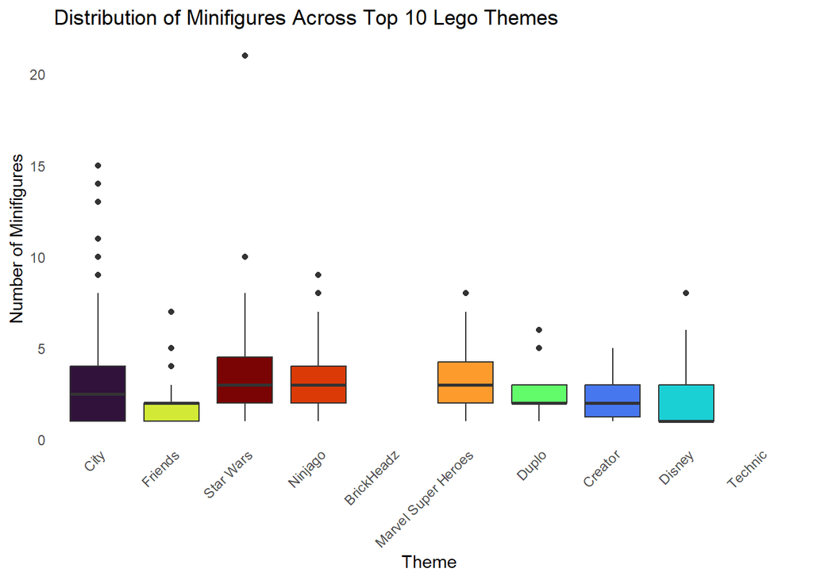

```r
top_themes <- lego_data %>%
  count(Theme, sort = TRUE) %>%
  top_n(10, n) %>%
  pull(Theme)


top_theme_data <- lego_data %>%
  filter(Theme %in% top_themes)


sets_per_theme <- top_theme_data %>%
  group_by(Theme) %>%
  summarize(total_sets = n())


top_theme_data <- top_theme_data %>%
  left_join(sets_per_theme, by = "Theme")


ggplot(top_theme_data, aes(x = reorder(Theme, -total_sets), y = Minifigures, fill = Theme)) +
  geom_boxplot() +
  scale_fill_viridis_d(option = "turbo") +
  labs(
    title = "Distribution of Minifigures Across Top 10 Lego Themes",
    x = "Theme",
    y = "Number of Minifigures"
  ) +
  theme_minimal() +
  theme(
    axis.text.x = element_text(angle = 45, hjust = 1),
    panel.grid.major = element_blank(),
    panel.grid.minor = element_blank(),
    legend.position = "none"
  )
```

# 4. Conclusions